# Part 1: Binary Logistic Regression

Katelin Seeto

1/20/2021

### Create pairs plot with GGally

Notes:  
* `ggpairs()` creates plots based on the variable you select (in this case we chose species) that shows multivariate correlations, distributions, and relationships both within and across variables  
* `fct_drop()` will drop factor levels where there’s no observations for those factor levels

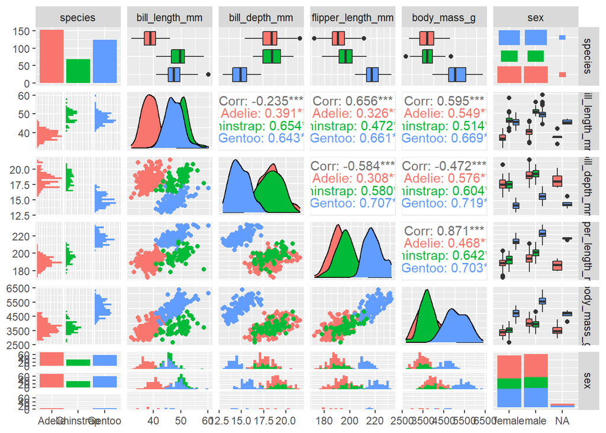

```r
penguins %>%
  select(species, bill_length_mm:sex) %>%
  ggpairs(aes(color = species))
```

Create a subset with only Adelie and Chinstrap penguins. Remember that species are listed stored as factor with levels

```r
adelie_chinstrap <- penguins %>%
  filter(species %in% c("Adelie", "Chinstrap")) %>%
# Since species was a factor, even if you filter out all observations for Gentoo, it still appears as a factor level even if it doesn't appear in your df, therefore must use fct_drop
  mutate(species = fct_drop(species))
```

Dataviz of Adelie and Chinstrap:

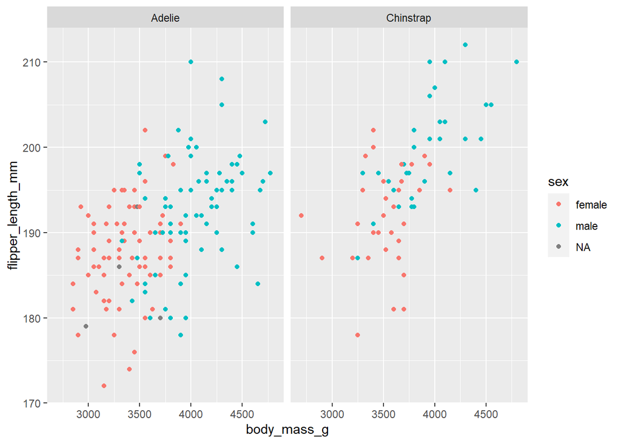

```r
ggplot(data = adelie_chinstrap, aes(x = body_mass_g, y = flipper_length_mm))+
  geom_point(aes(color = sex))+
  facet_wrap(~species)
```

Binary logistic regression to find the probability based on several variables that a penguin is either Adelie or Chinstrap

Variables we’re using:  
- body mass  
- flipper length  
- penguin sex

Notes:  
* `glm()` generalized linear model, can use for this binary logistic regression since outcome is still a linear regression of predictor variables, and binary logistic regression is the log odds of the probability and the fact that the model is generalized lets us specify what the link is on the left side of the equation

```r
adelie_chinstrap_blr <- glm(species ~ body_mass_g + flipper_length_mm + sex,
                            data = adelie_chinstrap,
                            family = "binomial") # reads like species as a function of body_mass_g and flipper_length_mm and sex, the data where I'm getting this is from adelie_chinstrap, and family specifies that the link on the left side of the equation is that we want the log odds with only two outcome variables
```

Take a look at the outcomes:

```r
adelie_chinstrap_blr # Calls up model outcomes and coefficients for each predictor value
```

```
##
## Call:  glm(formula = species ~ body_mass_g + flipper_length_mm + sex,
##     family = "binomial", data = adelie_chinstrap)
##
## Coefficients:
##       (Intercept)        body_mass_g  flipper_length_mm            sexmale
##        -3.161e+01         -8.576e-04          1.778e-01         -5.716e-01
##
## Degrees of Freedom: 213 Total (i.e. Null);  210 Residual
##   (6 observations deleted due to missingness)
## Null Deviance:       267.6
## Residual Deviance: 226.4     AIC: 234.4
```

```r
summary(adelie_chinstrap_blr)
```

```
##
## Call:
## glm(formula = species ~ body_mass_g + flipper_length_mm + sex,
##     family = "binomial", data = adelie_chinstrap)
##
## Deviance Residuals:
##     Min       1Q   Median       3Q      Max
## -1.9456  -0.8195  -0.5581   1.0065   2.3698
##
## Coefficients:
##                     Estimate Std. Error z value Pr(>|z|)
## (Intercept)       -3.161e+01  5.784e+00  -5.465 4.63e-08 ***
## body_mass_g       -8.576e-04  5.428e-04  -1.580    0.114
## flipper_length_mm  1.778e-01  3.236e-02   5.495 3.91e-08 ***
## sexmale           -5.716e-01  4.499e-01  -1.270    0.204
## ---
## Signif. codes:  0 '***' 0.001 '**' 0.01 '*' 0.05 '.' 0.1 ' ' 1
##
## (Dispersion parameter for binomial family taken to be 1)
##
##     Null deviance: 267.57  on 213  degrees of freedom
## Residual deviance: 226.45  on 210  degrees of freedom
##   (6 observations deleted due to missingness)
## AIC: 234.45
##
## Number of Fisher Scoring iterations: 4
```

Notes:  
* When we call levels(adelie_chinstrap$species) we notice that Adelie comes up 1st as level 0 and Chinstrap is therefore 1. So looking at a log linear expression, the left hand side of the equation is going to be the probability of Chinstrap, the log odds of the non zero

Interpreting Results:  
* Under estimate column in summary of model, we see that flipper_length_mm is a positive number, would interpret that as: With an increase in flipper length the odds of being a Chinstrap penguin increase.  
* Pr(>|z|) is the p value, notice flipper_length_mm has a significant p value

Let’s check that the significant results for flipper length actually make sense, by doing some visualization.

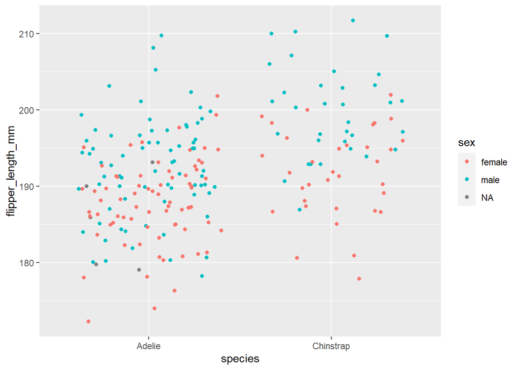

```r
ggplot(data = adelie_chinstrap, aes(x = species, y = flipper_length_mm))+
  geom_jitter(aes(color = sex))
```

Since interpreting log odds is difficult to explain, look at `broom::augment()` to find actual probabilities

Notes:  
* `broom::augment()` takes your actual dataset and tacks on actual model output would be each observation in the data. Only looks at variables that are in our model and then adds a column to the df called “.fitted” that reports probability of the outcome given the variable values. Then can compare to what it actually was.

What are the actual probabilities of being Chinstrap for each of the existing observation in our adelie_chinstrap df?

```r
blr_fitted <- adelie_chinstrap_blr %>% #start with your model
  broom::augment(type.predict = "response") # default results in col with original link, which for us is the log odds of the observation being a Chinstrap, but we want what the model would predict, so use type.predict = "response' which is the prediction calculated to be the probability of each outcome
```

Visualization plotting fitted probabilities:

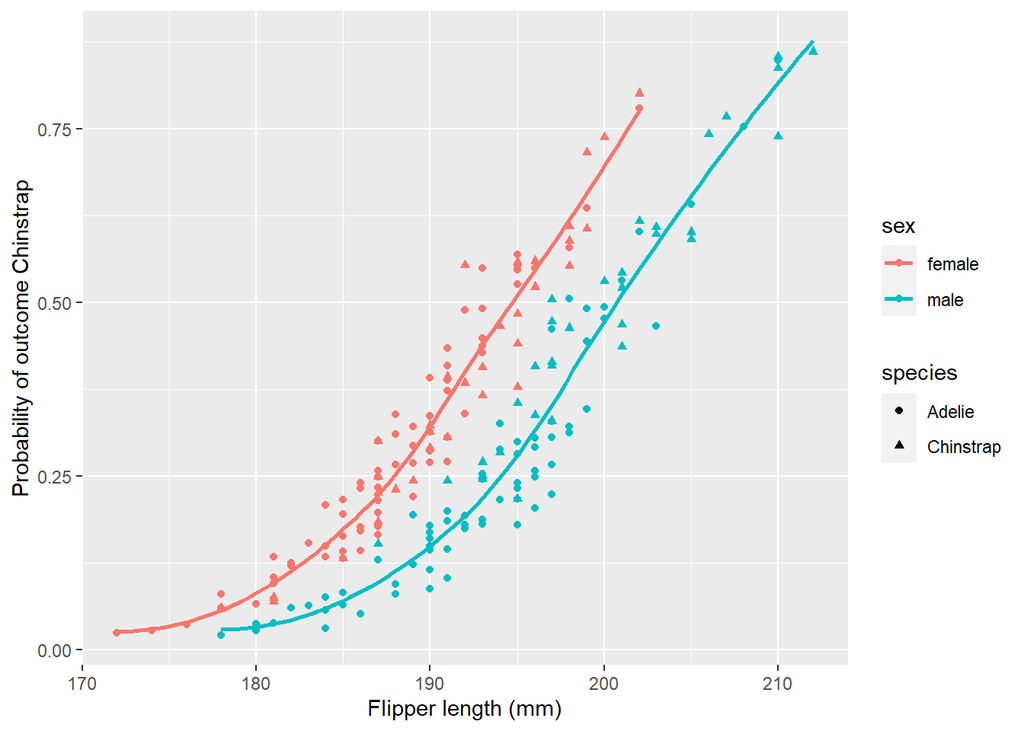

```r
ggplot(data = blr_fitted, aes(x= flipper_length_mm, y = .fitted))+
  geom_point(aes(color = sex, pch = species))+
  geom_smooth(aes(color = sex), se = FALSE)+
  labs( x = "Flipper length (mm)",
        y = "Probability of outcome Chinstrap")
```

Plot model based on different variables using `effect_plot()`:

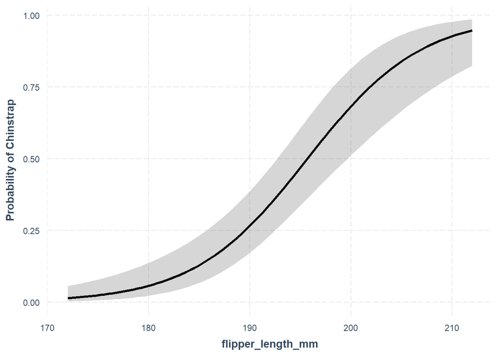

```r
effect_plot(adelie_chinstrap_blr,
            pred = flipper_length_mm,
            y.label = "Probability of Chinstrap",
            interval = TRUE) #interval includes confidence interval
```

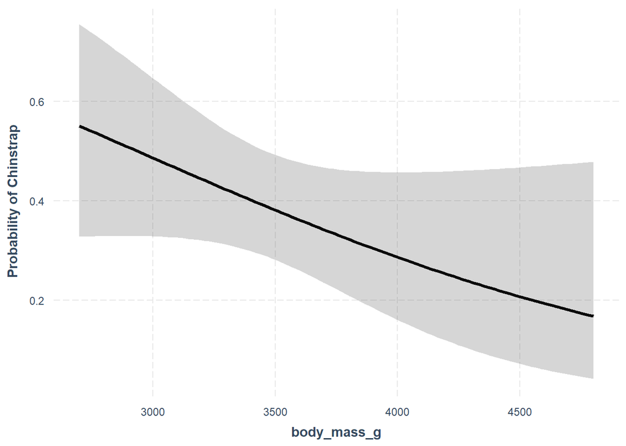

```r
effect_plot(adelie_chinstrap_blr,
            pred = body_mass_g,
            y.label = "Probability of Chinstrap",
            interval = TRUE)
```

What’s the probability that a female penguin weighing 3410g with a flipper length of 192mm is a Chinstrap?

```r
ex_1 <- predict(adelie_chinstrap_blr,
                data.frame(sex= "female",
                           body_mass_g = 3410,
                           flipper_length_mm = 192),
                type= "response") #default outcome is log odds so must specify type as "response" to get actual probability
ex_1
```

```
##         1
## 0.4028418
```